# Assignment 3: Classification Models Project

- Part 1: Running classification models we learned using help from Tutorial_6 on your dataset
- Part 2: Feature selection and Data splitting on the provided dataset
- Part 3: Running the classification models on the provided dataset
- Part 4: Performing accuracy analysis and comparing the models on the provided dataset

Team 12 Members:

- [Alicia Luna](https://github.com/aluna4)
- [Derek Dilger](https://github.com/derekdilger)
- [Gary Young](https://github.com/garyyoungcsc)
- [Ian Schultz](https://github.com/Ian-Sanity)
- [Jesus Cervantes](https://github.com/Jescer3)
- [Matthew Mendoza](https://github.com/matt2ology)
- [Thomas Jaramillo-Ochoa](https://github.com/tjaramillo452329)
- [Yun-jeong Lee](https://github.com/yunjeongiya)

## Part 1: Running classification models we learned using help from Tutorial_6 on your dataset

### Decision Tree Regressor

```python
import numpy as np
import csv
import matplotlib.pyplot as plt
import pandas as pd

with open('./data/uci_heartDisease_changed.csv', 'r') as f:
    reader = csv.reader(f)
    data = list(reader)

data_array = np.array(data)

X = data_array[1:, 4:5].astype(int)
y = data_array[1:, 13].astype(int)

print(X)
print(y)
```

[output not shown]

[output cut: 257 more lines]

```
 [241]
 [264]
 [193]
 [131]
 [236]
 [175]]
[0 2 1 0 0 0 3 0 2 1 0 0 2 0 0 0 1 0 0 0 0 0 1 3 4 0 0 0 0 3 0 2 1 0 0 0 3
 1 3 0 4 0 0 0 1 4 0 4 0 0 0 0 2 0 1 1 1 1 0 0 2 0 1 0 2 2 1 0 2 1 0 3 1 1
 1 0 1 0 0 3 0 0 0 3 0 0 0 0 0 0 0 3 0 0 0 1 2 3 0 0 0 0 0 0 3 0 2 1 2 3 1
 1 0 2 2 0 0 0 3 2 3 4 0 3 1 0 3 3 0 0 0 0 0 0 0 0 4 3 1 0 0 1 0 1 0 1 4 0
 0 0 0 0 0 4 3 1 1 1 2 0 0 4 0 0 0 0 0 0 1 0 3 0 1 0 4 1 0 1 0 0 3 2 0 0 1
 0 0 2 1 2 0 3 1 2 0 3 0 0 0 1 0 0 0 0 0 3 3 3 0 1 0 4 0 3 1 0 0 0 0 0 0 0
 0 3 1 0 0 0 3 2 0 2 1 0 0 3 2 1 0 0 0 0 0 2 0 2 2 1 3 0 0 1 0 0 0 0 0 0 0
 1 0 3 0 0 4 2 2 2 1 0 1 0 2 0 1 0 0 0 1 0 2 0 3 0 2 4 2 0 0 0 1 0 2 2 1 0
 3 1 1 2 3 1 0]
```

```python
from sklearn.tree import DecisionTreeRegressor
regressor = DecisionTreeRegressor(random_state=0)
regressor.fit(X, y)
```

```
DecisionTreeRegressor(random_state=0)
```

```python
y_pred = regressor.predict([[298]])
print("Predicted Heart Disease Diagnosis: % d\n" % y_pred)
```

```
Predicted Heart Disease Diagnosis:  1
```

arrange for creating a range of values from min value of X to max value of X with a difference of 0.01 between two consecutive values

```python
X_grid = np.arange(min(X), max(X), 0.01)
```

reshape for reshaping the data into a `len(X_grid)*1` array, i.e. to make a column out of the `X_grid` values

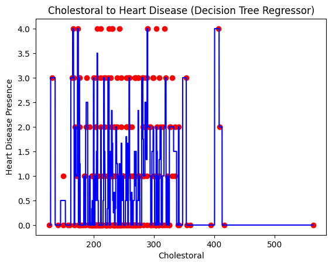

```python
X_grid = X_grid.reshape((len(X_grid), 1))

plt.scatter(X, y, color='red')
plt.plot(X_grid, regressor.predict(X_grid), color='blue')
plt.title('Cholestoral to Heart Disease (Decision Tree Regressor)')
plt.xlabel('Cholestoral')
plt.ylabel('Heart Disease Presence')
plt.show()
```

```python
from sklearn import tree
import graphviz

dot_data = tree.export_graphviz(
    regressor,
    out_file=None,
    feature_names=['Cholestoral'],
    filled=True,
    rounded=True,
)

graph = graphviz.Source(dot_data)
graph
```

[figure not shown]

### DATASET

```python
import matplotlib.pyplot as plt
import numpy as np

# Plot a confusion matrix.
# cm is the confusion matrix, names are the names of the classes.


def plot_confusion_matrix(cm, names, title='Confusion matrix', cmap=plt.cm.Blues):
    plt.imshow(cm, interpolation='nearest', cmap=cmap)
    plt.title(title)
    plt.colorbar()
    tick_marks = np.arange(len(names))
    plt.xticks(tick_marks, names, rotation=45)
    plt.yticks(tick_marks, names)
    plt.tight_layout()
    plt.ylabel('True label')
    plt.xlabel('Predicted label')
```

```python
import pandas as pd
import seaborn as sns

data_set = pd.read_csv('./data/uci_heartDisease_changed.csv', header='infer')
data = data_set.replace('?', np.NaN)
data
```

|  | age | sex | cp | trestbps | chol | fbs | restecg | thalach | exang | oldpeak | slope | ca | thal | num |
| --- | --- | --- | --- | --- | --- | --- | --- | --- | --- | --- | --- | --- | --- | --- |
| 0 | 63 | 1 | 1 | 145 | 233 | 1 | 2 | 150 | 0 | 2.3 | 3 | 0 | 6 | 0 |
| 1 | 67 | 1 | 4 | 160 | 286 | 0 | 2 | 108 | 1 | 1.5 | 2 | 3 | 3 | 2 |
| 2 | 67 | 1 | 4 | 120 | 229 | 0 | 2 | 129 | 1 | 2.6 | 2 | 2 | 7 | 1 |
| 3 | 37 | 1 | 3 | 130 | 250 | 0 | 0 | 187 | 0 | 3.5 | 3 | 0 | 3 | 0 |
| 4 | 41 | 0 | 2 | 130 | 204 | 0 | 2 | 172 | 0 | 1.4 | 1 | 0 | 3 | 0 |
| ... | ... | ... | ... | ... | ... | ... | ... | ... | ... | ... | ... | ... | ... | ... |
| 298 | 45 | 1 | 1 | 110 | 264 | 0 | 0 | 132 | 0 | 1.2 | 2 | 0 | 7 | 1 |
| 299 | 68 | 1 | 4 | 144 | 193 | 1 | 0 | 141 | 0 | 3.4 | 2 | 2 | 7 | 2 |
| 300 | 57 | 1 | 4 | 130 | 131 | 0 | 0 | 115 | 1 | 1.2 | 2 | 1 | 7 | 3 |
| 301 | 57 | 0 | 2 | 130 | 236 | 0 | 2 | 174 | 0 | 0.0 | 2 | 1 | 3 | 1 |
| 302 | 38 | 1 | 3 | 138 | 175 | 0 | 0 | 173 | 0 | 0.0 | 1 | 1 | 3 | 0 |

303 rows × 14 columns

```python
data['num'] = data['num'].replace([0, 1], 'low risk')
data['num'] = data['num'].replace([2], 'risky')
data['num'] = data['num'].replace([3, 4], 'high risk')
data
```

|  | age | sex | cp | trestbps | chol | fbs | restecg | thalach | exang | oldpeak | slope | ca | thal | num |
| --- | --- | --- | --- | --- | --- | --- | --- | --- | --- | --- | --- | --- | --- | --- |
| 0 | 63 | 1 | 1 | 145 | 233 | 1 | 2 | 150 | 0 | 2.3 | 3 | 0 | 6 | low risk |
| 1 | 67 | 1 | 4 | 160 | 286 | 0 | 2 | 108 | 1 | 1.5 | 2 | 3 | 3 | risky |
| 2 | 67 | 1 | 4 | 120 | 229 | 0 | 2 | 129 | 1 | 2.6 | 2 | 2 | 7 | low risk |
| 3 | 37 | 1 | 3 | 130 | 250 | 0 | 0 | 187 | 0 | 3.5 | 3 | 0 | 3 | low risk |
| 4 | 41 | 0 | 2 | 130 | 204 | 0 | 2 | 172 | 0 | 1.4 | 1 | 0 | 3 | low risk |
| ... | ... | ... | ... | ... | ... | ... | ... | ... | ... | ... | ... | ... | ... | ... |
| 298 | 45 | 1 | 1 | 110 | 264 | 0 | 0 | 132 | 0 | 1.2 | 2 | 0 | 7 | low risk |
| 299 | 68 | 1 | 4 | 144 | 193 | 1 | 0 | 141 | 0 | 3.4 | 2 | 2 | 7 | risky |
| 300 | 57 | 1 | 4 | 130 | 131 | 0 | 0 | 115 | 1 | 1.2 | 2 | 1 | 7 | high risk |
| 301 | 57 | 0 | 2 | 130 | 236 | 0 | 2 | 174 | 0 | 0.0 | 2 | 1 | 3 | low risk |
| 302 | 38 | 1 | 3 | 138 | 175 | 0 | 0 | 173 | 0 | 0.0 | 1 | 1 | 3 | low risk |

303 rows × 14 columns

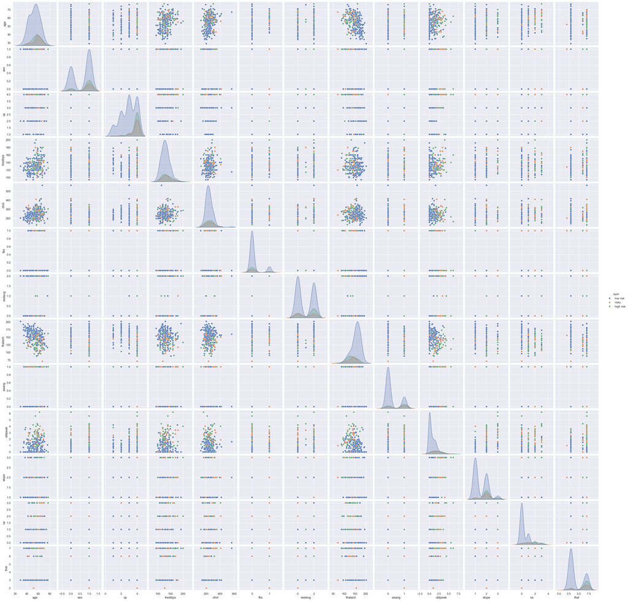

```python
# Paired plot using seaborn
sns.set()
sns.pairplot(
    data[
        [
            'age',
            'sex',
            'cp',
            'trestbps',
            'chol',
            'fbs',
            'restecg',
            'thalach',
            'exang',
            'oldpeak',
            'slope',
            'ca',
            'thal',
            'num'
        ]
    ],
    hue='num',
    diag_kind="kde"
)
```

```python
pd.crosstab([data['age'], data['chol']], data['num'])
```

| age | num chol | high risk | low risk | risky |
| --- | --- | --- | --- | --- |
| 29 | 204 | 0 | 1 | 0 |
| 34 | 182 | 0 | 1 | 0 |
|  | 210 | 0 | 1 | 0 |
| 35 | 183 | 0 | 1 | 0 |
|  | 192 | 0 | 1 | 0 |
| ... | ... | ... | ... | ... |
| 71 | 265 | 0 | 1 | 0 |
|  | 302 | 0 | 1 | 0 |
| 74 | 269 | 0 | 1 | 0 |
| 76 | 197 | 0 | 1 | 0 |
| 77 | 304 | 1 | 0 | 0 |

299 rows × 3 columns

### Data Tree Classifier

```python
from sklearn import tree

Y = pd.DataFrame(data, columns=['num'])
X = data.drop(['num'], axis=1)

clf = tree.DecisionTreeClassifier(criterion='entropy', max_depth=3)
clf = clf.fit(X, Y)

X
```

|  | age | sex | cp | trestbps | chol | fbs | restecg | thalach | exang | oldpeak | slope | ca | thal |
| --- | --- | --- | --- | --- | --- | --- | --- | --- | --- | --- | --- | --- | --- |
| 0 | 63 | 1 | 1 | 145 | 233 | 1 | 2 | 150 | 0 | 2.3 | 3 | 0 | 6 |
| 1 | 67 | 1 | 4 | 160 | 286 | 0 | 2 | 108 | 1 | 1.5 | 2 | 3 | 3 |
| 2 | 67 | 1 | 4 | 120 | 229 | 0 | 2 | 129 | 1 | 2.6 | 2 | 2 | 7 |
| 3 | 37 | 1 | 3 | 130 | 250 | 0 | 0 | 187 | 0 | 3.5 | 3 | 0 | 3 |
| 4 | 41 | 0 | 2 | 130 | 204 | 0 | 2 | 172 | 0 | 1.4 | 1 | 0 | 3 |
| ... | ... | ... | ... | ... | ... | ... | ... | ... | ... | ... | ... | ... | ... |
| 298 | 45 | 1 | 1 | 110 | 264 | 0 | 0 | 132 | 0 | 1.2 | 2 | 0 | 7 |
| 299 | 68 | 1 | 4 | 144 | 193 | 1 | 0 | 141 | 0 | 3.4 | 2 | 2 | 7 |
| 300 | 57 | 1 | 4 | 130 | 131 | 0 | 0 | 115 | 1 | 1.2 | 2 | 1 | 7 |
| 301 | 57 | 0 | 2 | 130 | 236 | 0 | 2 | 174 | 0 | 0.0 | 2 | 1 | 3 |
| 302 | 38 | 1 | 3 | 138 | 175 | 0 | 0 | 173 | 0 | 0.0 | 1 | 1 | 3 |

303 rows × 13 columns

The classifier above is also constrained to generate trees with a maximum depth equals to 3. Next, the classifier is trained on the labeled data using the `fit()` function.

```python
import graphviz
dot_data = tree.export_graphviz(clf, out_file=None)
graph = graphviz.Source(dot_data)

dot_data = tree.export_graphviz(clf, out_file=None,
                                feature_names=X.columns,
                                class_names=['low risk', 'risky', 'high risk'],
                                filled=True, rounded=True,
                                special_characters=True)
graph = graphviz.Source(dot_data)
graph
```

[figure not shown]

Test Examples:

```python
testData = [[42, 0, 3, 150, 229, 0, 2, 171, 0, 1.9, 3, 0, 6, 'risky'],
            [65, 1, 4, 128, 126, 1, 0, 168, 1, 0.4, 2, 1, 7, 'low risk'],
            [37, 0, 2, 130, 264, 0, 1, 99, 1, 1.6, 2, 1, 3, 'low risk'],
            [55, 1, 1, 170, 220, 0, 2, 123, 0, 2.3, 2, 0, 6, 'high risk']]
testData = pd.DataFrame(testData, columns=data.columns)
testData
```

|  | age | sex | cp | trestbps | chol | fbs | restecg | thalach | exang | oldpeak | slope | ca | thal | num |
| --- | --- | --- | --- | --- | --- | --- | --- | --- | --- | --- | --- | --- | --- | --- |
| 0 | 42 | 0 | 3 | 150 | 229 | 0 | 2 | 171 | 0 | 1.9 | 3 | 0 | 6 | risky |
| 1 | 65 | 1 | 4 | 128 | 126 | 1 | 0 | 168 | 1 | 0.4 | 2 | 1 | 7 | low risk |
| 2 | 37 | 0 | 2 | 130 | 264 | 0 | 1 | 99 | 1 | 1.6 | 2 | 1 | 3 | low risk |
| 3 | 55 | 1 | 1 | 170 | 220 | 0 | 2 | 123 | 0 | 2.3 | 2 | 0 | 6 | high risk |

```python
testY = pd.DataFrame(testData, columns=['num'])
testX = testData.drop(['num'], axis=1)

predY = clf.predict(testX)
predictions = pd.concat(
    [testData['age'], pd.Series(predY, name='Predicted Class')], axis=1)
predictions
```

|  | age | Predicted Class |
| --- | --- | --- |
| 0 | 42 | low risk |
| 1 | 65 | low risk |
| 2 | 37 | low risk |
| 3 | 55 | low risk |

```
[[0 1 0]
 [0 2 0]
 [0 1 0]]
Accuracy on test data is 0.50
F1 score on test data is 0.33
Precision Score on test data is 0.25
Recall score on test data is 0.50
              precision    recall  f1-score   support

   high risk       0.00      0.00      0.00         1
    low risk       0.50      1.00      0.67         2
       risky       0.00      0.00      0.00         1

    accuracy                           0.50         4
   macro avg       0.17      0.33      0.22         4
weighted avg       0.25      0.50      0.33         4
```

[figure not shown]

```python
from sklearn.metrics import accuracy_score, confusion_matrix, f1_score, precision_score, recall_score, classification_report

confusion = confusion_matrix(testY, predY)
print(confusion)

plot_confusion_matrix(confusion, data.num.unique(),
                      title='Confusion matrix', cmap=plt.cm.Blues)

print('Accuracy on test data is %.2f' % (accuracy_score(testY, predY)))
print('F1 score on test data is %.2f' %
      (f1_score(testY, predY, average='weighted')))
print('Precision Score on test data is %.2f' %
      (precision_score(testY, predY, average='weighted')))
print('Recall score on test data is %.2f' %
      (recall_score(testY, predY, average='weighted')))
print(classification_report(testY, predY))
```

[output not shown]

[output cut: 37 more lines]

[output not shown]

```
['low risk' 'low risk' 'low risk' 'low risk']
['low risk' 'low risk' 'low risk' 'low risk']
['low risk' 'low risk' 'low risk' 'low risk']
['low risk' 'low risk' 'low risk' 'low risk']
['low risk' 'low risk' 'low risk' 'low risk']
['low risk' 'low risk' 'low risk' 'low risk']
['low risk' 'low risk' 'low risk' 'low risk']
['low risk' 'low risk' 'low risk' 'low risk']
['low risk' 'low risk' 'low risk' 'low risk']
['low risk' 'low risk' 'low risk' 'low risk']
```

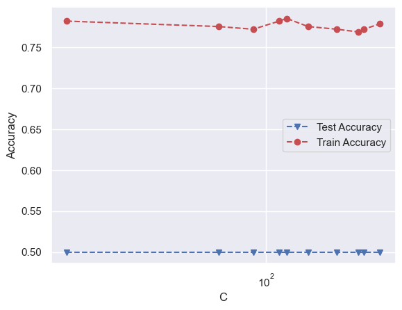

```python
from sklearn.linear_model import LogisticRegression

C = [20, 68, 90, 111, 118, 140, 177, 210, 220, 250]

LRtestAcc = []
LRtrainAcc = []

for param in C:
    clf = LogisticRegression(C=param)
    clf.fit(X, Y)
    log_reg_pred = clf.predict(testX)
    log_reg_pred_train = clf.predict(X)
    print(log_reg_pred)
    LRtestAcc.append(accuracy_score(testY, log_reg_pred))
    LRtrainAcc.append(accuracy_score(Y, log_reg_pred_train))

plt.plot(C, LRtestAcc, 'bv--', C, LRtrainAcc, 'ro--')
plt.legend(['Test Accuracy', 'Train Accuracy'])
plt.xlabel('C')
plt.xscale('log')
plt.ylabel('Accuracy')
```

### Naive Bayes Classifier

```python
from sklearn.naive_bayes import GaussianNB

clf_NB = GaussianNB()
clf_NB.fit(X, Y)
NB_pred = clf_NB.predict(testX)
print(NB_pred)

print('Accuracy on test data is %.2f' % (accuracy_score(testY, NB_pred)))
```

```
['low risk' 'risky' 'low risk' 'low risk']
Accuracy on test data is 0.25
```

### Support Vector Machine (SVM) Classifier

#### Linear Decision Boundary

```
['low risk' 'low risk' 'low risk' 'low risk']
['low risk' 'low risk' 'low risk' 'low risk']
['low risk' 'low risk' 'low risk' 'low risk']
['low risk' 'low risk' 'low risk' 'low risk']
```

```
['high risk' 'low risk' 'low risk' 'low risk']
```

```
['high risk' 'low risk' 'low risk' 'low risk']
```

```
['low risk' 'low risk' 'low risk' 'low risk']
```

```
['high risk' 'low risk' 'low risk' 'low risk']
```

```
['high risk' 'low risk' 'low risk' 'low risk']
```

```
['low risk' 'low risk' 'low risk' 'low risk']
```

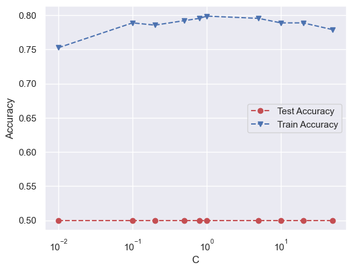

```python
from sklearn.svm import SVC

C = [0.01, 0.1, 0.2, 0.5, 0.8, 1, 5, 10, 20, 50]

SVMLtestAcc = []
SVMLtrainAcc = []

for param in C:
    clf = SVC(C=param, kernel='linear')
    clf.fit(X, Y)
    svml_pred = clf.predict(testX)
    svml_pred_train = clf.predict(X)
    print(svml_pred)
    SVMLtestAcc.append(accuracy_score(testY, svml_pred))
    SVMLtrainAcc.append(accuracy_score(Y, svml_pred_train))


plt.plot(C, SVMLtestAcc, 'ro--', C, SVMLtrainAcc, 'bv--')
plt.legend(['Test Accuracy', 'Train Accuracy'])
plt.xlabel('C')
plt.xscale('log')
plt.ylabel('Accuracy')
```

#### Non Linear Decision Boundary

```
['low risk' 'low risk' 'low risk' 'low risk']
['low risk' 'low risk' 'low risk' 'low risk']
['low risk' 'low risk' 'low risk' 'low risk']
['low risk' 'low risk' 'low risk' 'low risk']
['low risk' 'low risk' 'low risk' 'low risk']
['low risk' 'low risk' 'low risk' 'low risk']
['low risk' 'low risk' 'low risk' 'low risk']
['low risk' 'low risk' 'low risk' 'low risk']
['low risk' 'low risk' 'low risk' 'low risk']
['low risk' 'low risk' 'low risk' 'low risk']
```

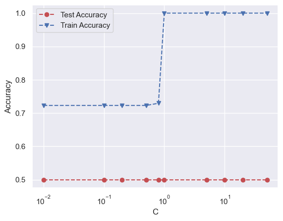

```python
C = [0.01, 0.1, 0.2, 0.5, 0.8, 1, 5, 10, 20, 50]


SVMLtestAcc = []
SVMLtrainAcc = []


for param in C:
    clf = SVC(C=param, kernel='rbf', gamma='auto')
    clf.fit(X, Y)
    svml_pred = clf.predict(testX)
    svml_pred_train = clf.predict(X)
    print(svml_pred)
    SVMLtestAcc.append(accuracy_score(testY, svml_pred))
    SVMLtrainAcc.append(accuracy_score(Y, svml_pred_train))

plt.plot(C, SVMLtestAcc, 'ro--', C, SVMLtrainAcc, 'bv--')
plt.legend(['Test Accuracy', 'Train Accuracy'])
plt.xlabel('C')
plt.xscale('log')
plt.ylabel('Accuracy')
```

#### K Nearest Neighbor (KNN) Classifier

```
['low risk' 'low risk' 'low risk' 'low risk']
['low risk' 'low risk' 'low risk' 'low risk']
['low risk' 'low risk' 'low risk' 'low risk']
```

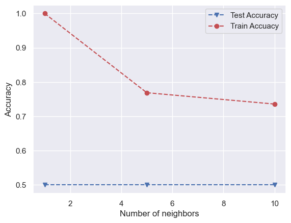

```python
from sklearn.neighbors import KNeighborsClassifier

numNeighbors = [1, 5, 10]
testAcc = []
trainAcc = []

for k in numNeighbors:
    clf = KNeighborsClassifier(n_neighbors=k, metric='minkowski', p=2)
    clf.fit(X, Y)
    knn_pred = clf.predict(testX)
    knn_pred_train = clf.predict(X)
    print(knn_pred)
    testAcc.append(accuracy_score(testY, knn_pred))
    trainAcc.append(accuracy_score(Y, knn_pred_train))

plt.plot(numNeighbors, testAcc, 'bv--', numNeighbors, trainAcc, 'ro--')
plt.legend(['Test Accuracy', 'Train Accuacy'])
plt.xlabel('Number of neighbors')
plt.ylabel('Accuracy')
```

## Part 2: Feature selection and Data splitting on the provided dataset

```
Model accuracy: 0.808
```

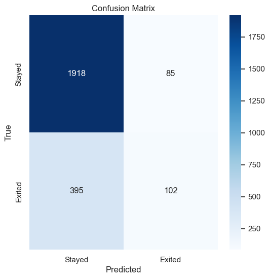

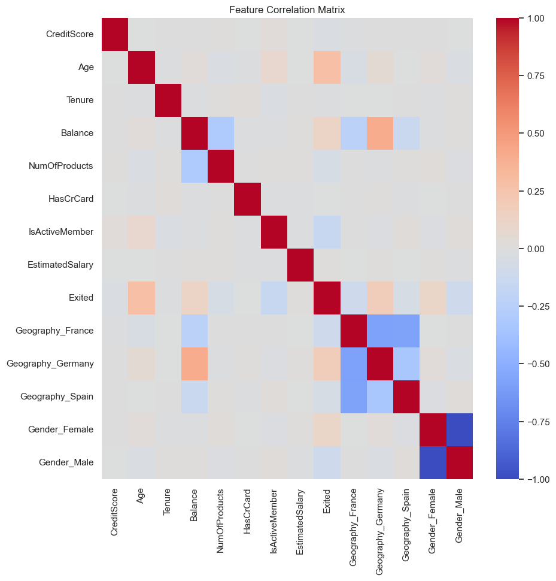

```python
import pandas as pd
import matplotlib.pyplot as plt
import seaborn as sns
from sklearn.model_selection import train_test_split
from sklearn.feature_selection import SelectKBest, f_classif
from sklearn.linear_model import LogisticRegression
from sklearn.metrics import accuracy_score, confusion_matrix
from sklearn.preprocessing import StandardScaler, OneHotEncoder
from sklearn.compose import ColumnTransformer
from sklearn.pipeline import Pipeline

# Load the dataset
data = pd.read_csv('./data/churn_modelling.csv')

# Drop irrelevant columns if they exist
columns_to_drop = ['RowNumber', 'CustomerId', 'Surname']
for col in columns_to_drop:
    if col in data.columns:
        data = data.drop(columns=col)

# Define X (features) and y (target variable)
X = data.drop('Exited', axis=1)
y = data['Exited']

# Preprocessing: Define column transformer for scaling and encoding
numerical_cols = X.select_dtypes(include=['int64', 'float64']).columns
categorical_cols = X.select_dtypes(include=['object']).columns

preprocessor = ColumnTransformer(
    transformers=[
        ('num', StandardScaler(), numerical_cols),
        ('cat', OneHotEncoder(), categorical_cols)
    ])

# Split the dataset
X_train, X_test, y_train, y_test = train_test_split(
    X, y, test_size=0.25, random_state=42)

# Create a pipeline with preprocessing, feature selection, and logistic regression
pipeline = Pipeline([
    ('preprocessor', preprocessor),
    ('feature_selection', SelectKBest(f_classif, k=10)),  # Select top 10 features
    ('classifier', LogisticRegression())
])

# Fit the pipeline on the training data
pipeline.fit(X_train, y_train)

# Predict and evaluate on the test set
y_pred = pipeline.predict(X_test)
accuracy = accuracy_score(y_test, y_pred)
print(f"Model accuracy: {accuracy}")

# Confusion Matrix
cm = confusion_matrix(y_test, y_pred)
plt.figure(figsize=(6, 6))
sns.heatmap(cm, annot=True, fmt='d', cmap='Blues', xticklabels=[
            'Stayed', 'Exited'], yticklabels=['Stayed', 'Exited'])
plt.xlabel('Predicted')
plt.ylabel('True')
plt.title('Confusion Matrix')
plt.show()

# Correlation Matrix (on the original data before feature selection)
data_encoded = pd.get_dummies(data)
corr = data_encoded.corr()
plt.figure(figsize=(10, 10))
sns.heatmap(corr, annot=False, cmap='coolwarm')
plt.title('Feature Correlation Matrix')
plt.show()
```

## Part 3: Running the classification models on the provided dataset

```python
from sklearn.metrics import accuracy_score
import matplotlib.pyplot as plt
import os
import pandas as pd

# getting the dataset
path = "."
filename = os.path.join(path, "data/churn_modelling.csv")
df = pd.read_csv(filename, na_values=['NA', '?'])
df = df.drop(['Geography', 'Gender'], axis=1)

tdf = df[0:999]
```

```python
Y = pd.DataFrame(df, columns=['Exited'])
X = df.drop(['Surname', 'Exited'], axis=1)

testY = pd.DataFrame(tdf, columns=['Exited'])
testX = tdf.drop(['Surname', 'Exited'], axis=1)
```

### Naive Bayes

```python
from sklearn.naive_bayes import GaussianNB

clf_NB = GaussianNB()
clf_NB.fit(X, Y)
NB_pred = clf_NB.predict(testX)

print('Accuracy on NB test data is %.2f' % (accuracy_score(testY, NB_pred)))
```

```
Accuracy on NB test data is 0.78
```

### K-Nearest Neighbor

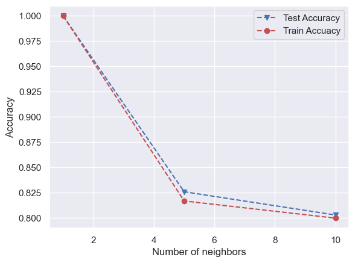

```python
from sklearn.neighbors import KNeighborsClassifier

numNeighbors = [1, 5, 10]
testAcc = []
trainAcc = []

for k in numNeighbors:
    clf = KNeighborsClassifier(n_neighbors=k, metric='minkowski', p=2)
    clf.fit(X, Y)
    knn_pred = clf.predict(testX)
    knn_pred_train = clf.predict(X)
    testAcc.append(accuracy_score(testY, knn_pred))
    trainAcc.append(accuracy_score(Y, knn_pred_train))

plt.plot(numNeighbors, testAcc, 'bv--', numNeighbors, trainAcc, 'ro--')
plt.legend(['Test Accuracy', 'Train Accuacy'])
plt.xlabel('Number of neighbors')
plt.ylabel('Accuracy')
```

```python
print('Accuracy on KNN test data is %.2f' % (accuracy_score(testY, knn_pred)))
```

```
Accuracy on KNN test data is 0.80
```

### Support Vector Machines

```python
from sklearn.svm import SVC

C = [0.1, 0.25, 0.5, 1, 3, 5]

SVMLtestAcc = []
SVMLtrainAcc = []

# test different values of C
for param in C:
    # we are using a linear kernel here
    clf = SVC(C=param, kernel='linear')
    # fit the model to the training data
    clf.fit(X, Y)
    # predict the test data using the model we just fit
    svml_pred = clf.predict(testX)
    # predict the training data using the model we just fit
    svml_pred_train = clf.predict(X)
    # append the accuracy score to the list
    SVMLtestAcc.append(accuracy_score(testY, svml_pred))
    # append the accuracy score to the list
    SVMLtrainAcc.append(accuracy_score(Y, svml_pred_train))
```

```python
print('Accuracy on SVM test data is %.2f' % (accuracy_score(testY, svml_pred)))
```

```
Accuracy on SVM test data is 0.80
```

### Decision Trees

```python
from sklearn import tree
import graphviz  # Adding graphviz to help graph the tree

clf = tree.DecisionTreeClassifier(criterion='entropy', max_depth=3)
clf = clf.fit(X, Y)
dot_data = tree.export_graphviz(clf, out_file=None)
graph = graphviz.Source(dot_data)

dot_data = tree.export_graphviz(clf, out_file=None,
                                feature_names=X.columns,
                                class_names=['Exited', 'Not-Exited'],
                                filled=True, rounded=True,
                                special_characters=True)
dt_graph = graphviz.Source(dot_data)
dt_graph
```

[figure not shown]

```python
predY = clf.predict(testX)

print('Accuracy on Decision Tree test data is %.2f' %
      (accuracy_score(testY, predY)))
```

```
Accuracy on Decision Tree test data is 0.84
```

### Logistic Regression

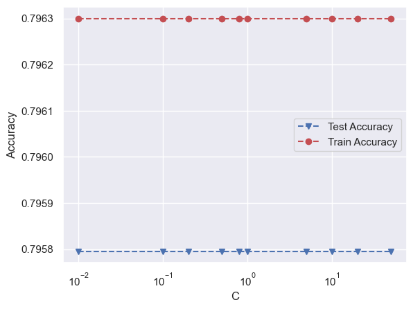

```python
from sklearn.linear_model import LogisticRegression

C = [0.01, 0.1, 0.2, 0.5, 0.8, 1, 5, 10, 20, 50]

LRtestAcc = []
LRtrainAcc = []

for param in C:
    clf = LogisticRegression(C=param)
    clf.fit(X, Y)
    log_reg_pred = clf.predict(testX)
    log_reg_pred_train = clf.predict(X)
    LRtestAcc.append(accuracy_score(testY, log_reg_pred))
    LRtrainAcc.append(accuracy_score(Y, log_reg_pred_train))

plt.plot(C, LRtestAcc, 'bv--', C, LRtrainAcc, 'ro--')
plt.legend(['Test Accuracy', 'Train Accuracy'])
plt.xlabel('C')
plt.xscale('log')
plt.ylabel('Accuracy')
```

```python
print('Accuracy on Logistic Regression test data is %.2f' %
      (accuracy_score(testY, log_reg_pred))
      )
```

```
Accuracy on Logistic Regression test data is 0.80
```

## Part 4: Performing accuracy analysis and comparing the models on the provided dataset

| ML Model | Accuracy on Test Set in Percent |
| --- | --- |
| Naive Bayes | 78 |
| KNN | 80 |
| SVM | 80 |
| DT | 84 |
| Logit | 80 |

See Running the classification models on the provided dataset to see how the above percentages were computed.

### Some graphs

How accuracy changes based on number of neighbors:

[figure not shown]

### The decision tree

[figure not shown]

Based on our accuracy analysis, following this tree leads to the right categorization around 80% of the time, depending on the model.

[figure not shown]